# OzoneModel: one easy App for ozone level prediction

5/17/2019

## What’s OzoneModel

This is a very quick introduction to “**OzoneModel**”, a very straightforward App to generate a model predicting atmospheric ozone levels, based on the observations taken in the summer months of 1973.

## The dataset

The dataset on which the analyses are conducted is the *airquality dataset*, embedded in R. It consists of 6 columns which contain

- the ozone levels
- the measurments of 3 other variables influencing ozone levels, i.e. Solar radiation (lang), Wind speed (mph), Temperature (°F)
- the id for month (from May to September) and day

| Ozone | Solar.R | Wind | Temp | Month | Day |
| --- | --- | --- | --- | --- | --- |
| 41 | 190 | 7.4 | 67 | 5 | 1 |
| 36 | 118 | 8.0 | 72 | 5 | 2 |
| 12 | 149 | 12.6 | 74 | 5 | 3 |
| 18 | 313 | 11.5 | 62 | 5 | 4 |

## The commands

The App asks the operator to select with a slider the month or months to consider in order to predict the model, and to check the boxes for at least 1 to all 3 predictors (Solar radiation, Wind speed and Temperature) to insert in the model

The app also generates a timeline graph showing the levels of ozone in the months selected (NA values are represented as interruption in the timeline)

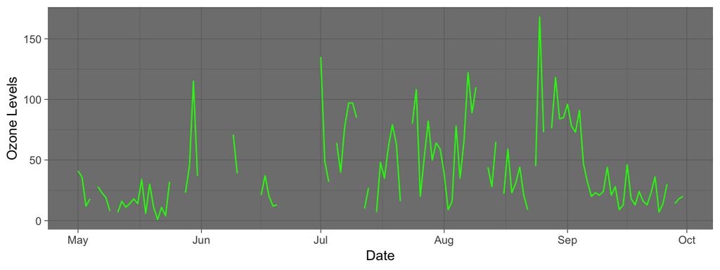

## The model

Once selected the months to consider and which predictor/predictors to use in generating the linear model, the App returns the coefficients for the Intercept and each predictor selected, after having trained a linear model to predict ozone levels.

In this example, we show the output for a model considering *Solar Radiation* and *Temperature* in the months of August and September.

```
  (Intercept)       Solar.R          Temp
-195.63601656    0.08276501    2.82355177
```